# Analyzing Ford GoBick Trip Data

## by (Fatimah Al-Matar)

## Preliminary Wrangling

> This data set includes information about individual rides made in a bike-sharing system covering the greater San Francisco Bay area.

### 1- Gathering Data

|  | duration_sec | start_time | end_time | start_station_id | start_station_name | start_station_latitude | start_station_longitude | end_station_id | end_station_name | end_station_latitude | end_station_longitude | bike_id | user_type | member_birth_year | member_gender | bike_share_for_all_trip |
| --- | --- | --- | --- | --- | --- | --- | --- | --- | --- | --- | --- | --- | --- | --- | --- | --- |
| 0 | 52185 | 2019-02-28 17:32:10.1450 | 2019-03-01 08:01:55.9750 | 21.0 | Montgomery St BART Station (Market St at 2nd St) | 37.789625 | -122.400811 | 13.0 | Commercial St at Montgomery St | 37.794231 | -122.402923 | 4902 | Customer | 1984.0 | Male | No |
| 1 | 42521 | 2019-02-28 18:53:21.7890 | 2019-03-01 06:42:03.0560 | 23.0 | The Embarcadero at Steuart St | 37.791464 | -122.391034 | 81.0 | Berry St at 4th St | 37.775880 | -122.393170 | 2535 | Customer | NaN | NaN | No |
| 2 | 61854 | 2019-02-28 12:13:13.2180 | 2019-03-01 05:24:08.1460 | 86.0 | Market St at Dolores St | 37.769305 | -122.426826 | 3.0 | Powell St BART Station (Market St at 4th St) | 37.786375 | -122.404904 | 5905 | Customer | 1972.0 | Male | No |
| 3 | 36490 | 2019-02-28 17:54:26.0100 | 2019-03-01 04:02:36.8420 | 375.0 | Grove St at Masonic Ave | 37.774836 | -122.446546 | 70.0 | Central Ave at Fell St | 37.773311 | -122.444293 | 6638 | Subscriber | 1989.0 | Other | No |
| 4 | 1585 | 2019-02-28 23:54:18.5490 | 2019-03-01 00:20:44.0740 | 7.0 | Frank H Ogawa Plaza | 37.804562 | -122.271738 | 222.0 | 10th Ave at E 15th St | 37.792714 | -122.248780 | 4898 | Subscriber | 1974.0 | Male | Yes |

### 2- Assessing Data

1- The dataset has many missing values.

2- Invalid data type in (start_time, end_time, start_station_id, end_station_id,bike_id, member_gender, user_type)

3- The trip duration is in seconds.

4- some columns are not necessary in the analysis and visualization

### 3- Cleaning Data

|  | duration_sec | duration_minutes | duration_hours | member_birth_year | member_age |
| --- | --- | --- | --- | --- | --- |
| count | 174952.000000 | 174952.000000 | 174952.000000 | 174952.000000 | 174952.000000 |
| mean | 704.002744 | 11.733379 | 13.456165 | 1984.803135 | 36.196865 |
| std | 1642.204905 | 27.370082 | 4.734282 | 10.118731 | 10.118731 |
| min | 61.000000 | 1.016667 | 0.000000 | 1878.000000 | 20.000000 |
| 25% | 323.000000 | 5.383333 | 9.000000 | 1980.000000 | 29.000000 |
| 50% | 510.000000 | 8.500000 | 14.000000 | 1987.000000 | 34.000000 |
| 75% | 789.000000 | 13.150000 | 17.000000 | 1992.000000 | 41.000000 |
| max | 84548.000000 | 1409.133333 | 23.000000 | 2001.000000 | 143.000000 |

## Univariate Exploration

### Exploring the distribution of the Trip Duration in Minutes

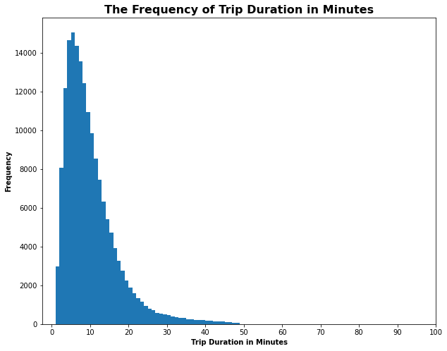

### Exploring the Distribution of Bike Ride Days

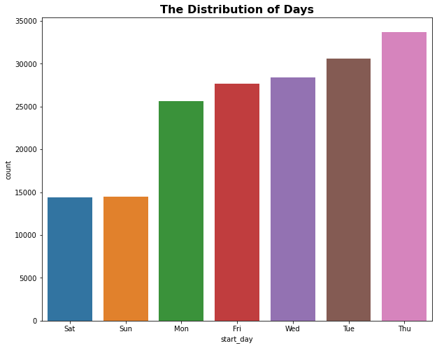

**The above Bar Chart shows that Thursdays appear to be the most frequent days that people prefer to ride the bikes on, wherease Sundays and Saturdays are the least**

## Bivariate Exploration

### Exploring the Relationship between the Member's Age and the Trip Duration in Minutes

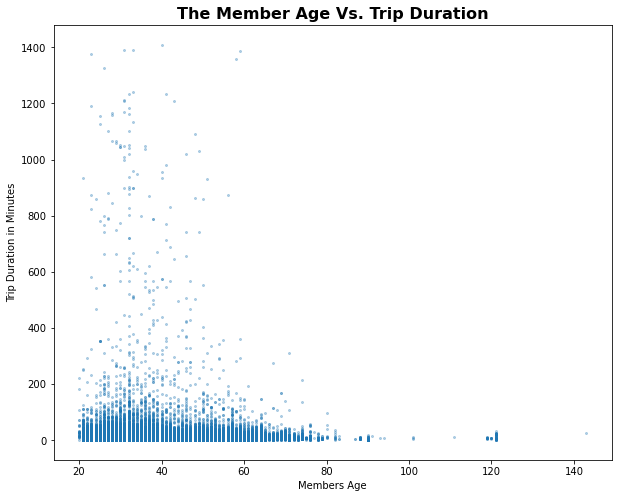

### Exploring the Relationship between Member's Gender and Start Days

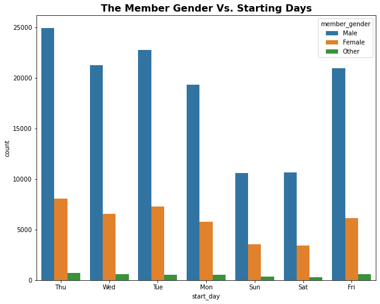

**Males seem to like riding on Thursdays, Female also like Thursdays and like to ride on Tuesdays. Others gender seem to ride on Thursdays and Wednesdays**

## Multivariate Exploration

### Exploring the Relationship between the Members Age and Trip Duration based on their Gender

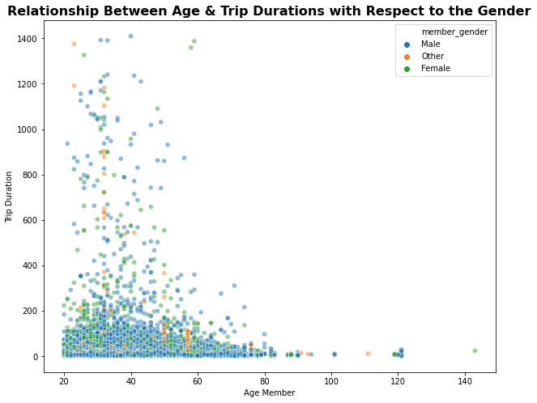

### Exploring the Relationship between the Riding Usage based on User Type and Gender

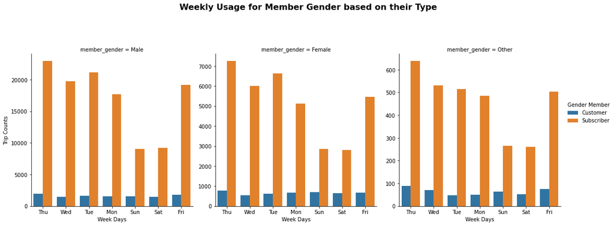

### Project Summary

In conclusion, we see that this data set is full of rich information and what I did is a high level analysis and invistigation and I may do deeper analyses in the near future. However, this data set discribes many things about the bike rides and riders using Ford's GoBike.

We clearly can see that there are some days that have more number of trips especially week days and this may be due to peoples preferences to ride the bikes to go to their works.

Subscribers are obviously more than customers and this may be due to their experience on how to ride such bikes.

Men seem to be using the bike more than women do.